# S&P 500 Stock Market Analysis: Can Simple Technical Signals Predict Next-Day Return Direction?

**CMSC 320 - Introduction to Data Science | Spring 2026 | Dr. Fardina Alam** **Jayant Maheshwari**

## Contributions

I worked on this project individually, so I'm responsible for everything below.

| Section | Contributor | Summary |
| --- | --- | --- |
| A: Project idea | Jayant Maheshwari | Came up with the questions about whether basic technical signals can predict next-day direction, and how this differs across sectors |
| B: Dataset Curation and Preprocessing | Jayant Maheshwari | Loaded the three Kaggle CSVs, fixed types, merged company metadata, and computed daily returns |
| C: Data Exploration and Summary Statistics | Jayant Maheshwari | Ran three statistical analyses: distribution of daily returns, one-way ANOVA across sectors, and a Welch t-test on volume |
| D: ML Algorithm Design/Development | Jayant Maheshwari | Built the lag-return / moving-average feature pipeline and chose Logistic Regression and Random Forest with balanced class weights |
| E: ML Algorithm Training and Test Data Analysis | Jayant Maheshwari | Trained models on a chronological 80/20 split, ran walk-forward cross-validation, tuned the decision threshold, and evaluated accuracy, ROC-AUC, F1, and per-sector accuracy |
| F: Visualization, Result Analysis, Conclusion | Jayant Maheshwari | Confusion matrix, ROC curve, feature-importance bar chart, and per-sector accuracy chart |
| G: Final Tutorial Report Creation | Jayant Maheshwari | Wrote the prose, organized the tutorial, and verified the notebook runs completely |

## Introduction

The S&P 500 tracks 500 of the largest U.S. publicly traded companies, weighted by market cap, and has been around since the 1950s. Trillions of dollars trade every day based on guesses about whether prices are going up or down, so I wanted to see whether simple, publicly available signals actually carry any real predictive power for next-day stock direction.

I've been into the stock market ever since I first got introduced to investing in high school. Back then, a lot of the "rule of thumb" ideas I heard were things like trading volume and simple moving averages, like comparing shorter-term and longer-term averages to guess momentum. For this project, I wanted to test whether those kinds of signals actually show anything useful when you evaluate them fairly.

This question matters for two reasons. First, the [weak-form Efficient Market Hypothesis](https://en.wikipedia.org/wiki/Efficient-market_hypothesis) (EMH) says that past prices alone shouldn't be able to predict future ones, so if even basic signals reliably predicted returns, that would push back on EMH. Second, retail investors actually use these rules of thumb, so it's worth checking if they hold up under a real test.

### Research Questions

- If I build a simple model using past returns, volume, and moving-average features, does it actually beat a baseline like "always predict up"?
- Are some sectors easier to model than others, or do these signals work better in certain sectors (like tech vs utilities)?
- When a model does well in one time period, does it still work later, or does the market "change the rules" over time?

## Imports

I'm using the standard scientific Python stack here: pandas for tables, numpy for arrays, matplotlib and seaborn for plots, scipy.stats for the hypothesis tests, and scikit-learn for the machine-learning pipeline. The `warnings.filterwarnings('ignore')` line just hides the convergence warnings scikit-learn prints when a linear model doesn't fully converge, which aren't actually errors.

```python
import pandas as pd
import numpy as np
import matplotlib.pyplot as plt
import seaborn as sns
from scipy.stats import f_oneway, ttest_ind
from sklearn.ensemble import RandomForestClassifier
from sklearn.linear_model import LogisticRegression
from sklearn.metrics import (accuracy_score, roc_auc_score, f1_score,
                             classification_report, confusion_matrix,
                             ConfusionMatrixDisplay, RocCurveDisplay)
from sklearn.preprocessing import StandardScaler
import warnings
warnings.filterwarnings('ignore')

sns.set_theme(style='whitegrid', palette='muted')
plt.rcParams['figure.dpi'] = 110
np.random.seed(7)
print("Libraries loaded.")
```

```
Libraries loaded.
```

## Data Curation

### Source

The dataset is [S&P 500 Stocks (daily updated)](https://www.kaggle.com/datasets/andrewmvd/sp-500-stocks) from Kaggle (Andrew MVD), released under the CC0 Public Domain license. It comes with three files:

| File | Description | Size |
| --- | --- | --- |
| `sp500_stocks.csv` | Daily OHLCV prices for each S&P 500 stock | ~1.9 M rows |
| `sp500_companies.csv` | Company metadata: sector, industry, market cap | 502 companies |
| `sp500_index.csv` | Aggregate daily S&P 500 index level | ~2,500 trading days |

One thing I want to flag about the data: the CSV technically lists 502 tickers, but 330 of them only contain NaN price rows. Those are placeholder entries for current S&P 500 constituents that didn't yet trade publicly during the dataset's coverage window (recent IPOs and spin-offs whose row schema exists but whose values were never backfilled). Only 172 tickers actually have real OHLCV history end to end, and those are the ones I work with below. This is a property of the source data, not something I introduced through cleaning, but I'd rather mention it now than have it be a surprise.

```python
DATA = 'data/archive/'

stocks    = pd.read_csv(DATA + 'sp500_stocks.csv')
companies = pd.read_csv(DATA + 'sp500_companies.csv')
index_df  = pd.read_csv(DATA + 'sp500_index.csv')

print('sp500_stocks.csv   :', stocks.shape[0], 'rows,', stocks.shape[1], 'columns')
print('sp500_companies.csv:', companies.shape[0], 'rows,', companies.shape[1], 'columns')
print('sp500_index.csv    :', index_df.shape[0], 'rows,', index_df.shape[1], 'columns')

nominal = stocks['Symbol'].nunique()
populated = stocks.dropna(subset=['Close'])['Symbol'].nunique()
print()
print('Nominal tickers in file:', nominal)
print('Tickers with real price history:', populated)
print('Placeholder/empty tickers (excluded by dropna):', nominal - populated)

stocks.head(3)
```

```
sp500_stocks.csv   : 1891536 rows, 8 columns
sp500_companies.csv: 502 rows, 16 columns
sp500_index.csv    : 2517 rows, 2 columns

Nominal tickers in file: 502
Tickers with real price history: 172
Placeholder/empty tickers (excluded by dropna): 330
```

|  | Date | Symbol | Adj Close | Close | High | Low | Open | Volume |
| --- | --- | --- | --- | --- | --- | --- | --- | --- |
| 0 | 2010-01-04 | MMM | NaN | NaN | NaN | NaN | NaN | NaN |
| 1 | 2010-01-05 | MMM | NaN | NaN | NaN | NaN | NaN | NaN |
| 2 | 2010-01-06 | MMM | NaN | NaN | NaN | NaN | NaN | NaN |

### Preprocessing Steps

This CSV is not ready for analysis yet. The steps below fix data types, attach sector labels, sort the data so per-stock time-series operations actually work, and compute the daily return for the rest of the analysis.

1. Parse dates: convert the `Date` column to `datetime64`.
2. Coerce numerics: prices and volume are sometimes stored as strings, so I use `pd.to_numeric(..., errors='coerce')` to push non-numeric entries to NaN.
3. Standardize column names to lowercase with underscores instead of spaces.
4. Merge sector labels by left-joining the company metadata on `symbol`.
5. Sort chronologically per stock so `pct_change()` runs within each ticker, not across them.
6. Compute the daily return: $r_t = (P_t - P_{t-1}) / P_{t-1}$ per stock using `groupby` + [`pct_change`](https://pandas.pydata.org/docs/reference/api/pandas.Series.pct_change.html).
7. Drop rows with NaN in `daily_return`, `close`, `volume`, or `sector`. This step quietly removes the 330 placeholder tickers I mentioned earlier.
8. Filter to 2015 onward so I'm focused on a more modern market regime, while still covering the COVID crash, the 2022 bear market, and the 2023-24 rally. The window isn't perfectly stable, but it's long enough to be useful without dragging in the structurally different early-2010s low-rate era.

```python
stocks['Date'] = pd.to_datetime(stocks['Date'])
for col in ['Open', 'High', 'Low', 'Close', 'Adj Close', 'Volume']:
    stocks[col] = pd.to_numeric(stocks[col], errors='coerce')

stocks.columns    = stocks.columns.str.lower().str.replace(' ', '_')
companies.columns = companies.columns.str.lower().str.replace(' ', '_')

stocks = stocks.merge(companies[['symbol', 'sector']], on='symbol', how='left')
stocks = stocks.sort_values(['symbol', 'date']).reset_index(drop=True)

# pct_change has to run inside each ticker, otherwise day 1 of one stock pulls from another
stocks['daily_return'] = stocks.groupby('symbol')['close'].pct_change()

df = stocks.dropna(subset=['daily_return', 'close', 'volume', 'sector'])
df = df[df['date'] >= '2015-01-01'].copy()

print('Clean dataset :', df.shape[0], 'rows')
print('Unique tickers:', df['symbol'].nunique())
print('Sectors       :', df['sector'].nunique())
print('Date range    :', df['date'].min().date(), 'to', df['date'].max().date())
df[['date','symbol','sector','close','volume','daily_return']].head(5)
```

```
Clean dataset : 422193 rows
Unique tickers: 172
Sectors       : 11
Date range    : 2015-01-02 to 2024-12-20
```

|  | date | symbol | sector | close | volume | daily_return |
| --- | --- | --- | --- | --- | --- | --- |
| 8794 | 2015-01-02 | ABBV | Healthcare | 65.889999 | 5086100.0 | 0.006876 |
| 8795 | 2015-01-05 | ABBV | Healthcare | 64.650002 | 8007400.0 | -0.018819 |
| 8796 | 2015-01-06 | ABBV | Healthcare | 64.330002 | 5483700.0 | -0.004950 |
| 8797 | 2015-01-07 | ABBV | Healthcare | 66.930000 | 8283300.0 | 0.040417 |
| 8798 | 2015-01-08 | ABBV | Healthcare | 67.629997 | 7949000.0 | 0.010459 |

## Exploratory Data Analysis

Before I get into the actual model, I want to do some exploratory analysis to figure out what the data actually looks like and decide which features even make sense to feed in. I run three different tests below, and each one helps me decide something specific about how I should build the model.

The first is descriptive statistics on daily returns, so I can see whether assuming normality anywhere would be a bad idea. The second is a one-way ANOVA on sector means, which tells me whether I should pool all sectors together or treat them separately. The third is a Welch t-test on whether trading volume is related to the size of a price move, which is the reason I'm even considering a volume feature in the model. Each one comes with a plot and a short conclusion, and I'm using $\alpha = 0.05$ throughout.

### Analysis 1: Distribution of Daily Returns

I use descriptive statistics (mean, standard deviation, skewness, excess kurtosis) and a histogram to summarize the shape of daily returns across all the S&P 500 stocks in my dataset. [Excess kurtosis](https://en.wikipedia.org/wiki/Kurtosis#Excess_kurtosis) measures how heavy the tails are compared to a normal distribution. 0 means roughly normal, anything noticeably above 0 means fat tails, where extreme moves happen way more often than a bell curve would predict. Daily stock returns are pretty famous for sitting well above 0.

My hypothesis here is that daily returns are roughly normally distributed with a mean close to 0.

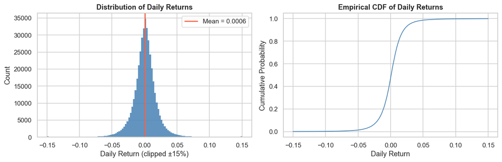

```
Summary statistics:
count    422193.000000
mean          0.000585
std           0.020530
min          -0.406583
25%          -0.008368
50%           0.000753
75%           0.009726
max           0.676812

Skewness : 0.2033
Kurtosis : 21.9958  (normal = 0 for excess)
```

```python
returns = df['daily_return']

# clipping just for the histogram, the stats below use the raw returns
clipped = returns.clip(-0.15, 0.15)

fig, axes = plt.subplots(1, 2, figsize=(12, 4))

axes[0].hist(clipped, bins=120, color='steelblue', edgecolor='none', alpha=0.85)
axes[0].axvline(returns.mean(), color='tomato', linewidth=1.8, label=f'Mean = {returns.mean():.4f}')
axes[0].set_xlabel('Daily Return (clipped ±15%)')
axes[0].set_ylabel('Count')
axes[0].set_title('Distribution of Daily Returns', fontweight='bold')
axes[0].legend()

sorted_r = np.sort(clipped)
axes[1].plot(sorted_r, np.linspace(0, 1, len(sorted_r)), color='steelblue', linewidth=1.2)
axes[1].set_xlabel('Daily Return')
axes[1].set_ylabel('Cumulative Probability')
axes[1].set_title('Empirical CDF of Daily Returns', fontweight='bold')

plt.tight_layout()
plt.savefig('figures/return_distribution.png', bbox_inches='tight')
plt.show()

print("Summary statistics:")
print(returns.describe().round(6).to_string())
print(f"\nSkewness : {returns.skew():.4f}")
print(f"Kurtosis : {returns.kurt():.4f}  (normal = 0 for excess)")
```

The mean daily return is just barely above zero (so there's a small positive drift), but the excess kurtosis is huge. Extreme up and down days happen way more often than a normal distribution would predict. This is a pretty well-known property of financial returns, and it tells me that any model that assumes normality is going to be misleading. It also means that even a model with decent average accuracy can still get hammered on rare extreme days.

### Analysis 2: Do Sectors Have Different Mean Returns? (One-Way ANOVA)

I run a [one-way ANOVA](https://en.wikipedia.org/wiki/One-way_analysis_of_variance) here, which asks: are the average daily returns the same across all 11 S&P 500 [GICS](https://en.wikipedia.org/wiki/Global_Industry_Classification_Standard) sectors (the Global Industry Classification Standard, which is the standard set of industry buckets like Tech, Healthcare, Financials, and so on), or is at least one sector behaving significantly differently from the rest? The test compares how spread out the sector means are vs how noisy the data is within each sector. A small p-value means at least one sector is meaningfully different.

- H0: All 11 sectors have the same mean daily return.
- H1: At least one sector's mean daily return differs.
- $\alpha = 0.05$.

```
One-Way ANOVA  F-statistic: 4.7212  p-value: 8.6486e-07
```

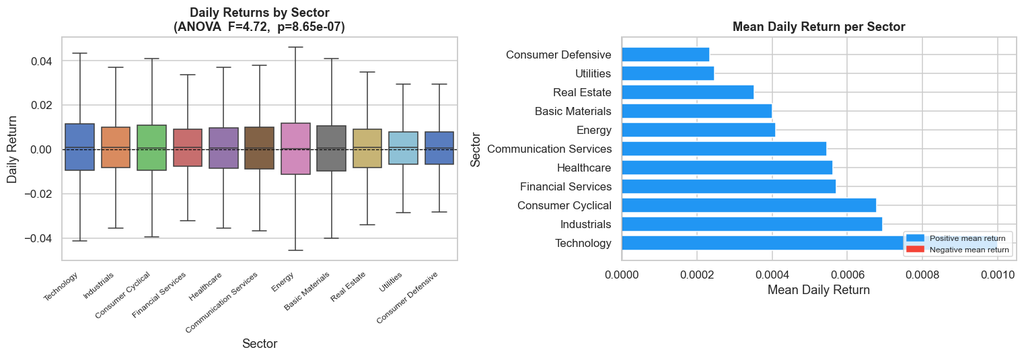

```python
sector_groups = [g['daily_return'].values for _, g in df.groupby('sector')]
sector_names  = list(df.groupby('sector').groups.keys())

f_stat, p_val = f_oneway(*sector_groups)
print('One-Way ANOVA  F-statistic:', round(f_stat, 4), ' p-value:', f'{p_val:.4e}')

sector_means = df.groupby('sector')['daily_return'].mean().sort_values(ascending=False)

fig, axes = plt.subplots(1, 2, figsize=(14, 5))

sector_order = sector_means.index.tolist()
sns.boxplot(data=df, x='sector', y='daily_return', order=sector_order,
            showfliers=False, ax=axes[0], palette='muted')
axes[0].axhline(0, color='black', linewidth=0.8, linestyle='--')
axes[0].set_xticklabels(axes[0].get_xticklabels(), rotation=40, ha='right', fontsize=8)
axes[0].set_xlabel('Sector')
axes[0].set_ylabel('Daily Return')
axes[0].set_title(f'Daily Returns by Sector\n(ANOVA  F={f_stat:.2f},  p={p_val:.2e})', fontweight='bold')

colors = ['#2196F3' if v >= 0 else '#F44336' for v in sector_means]
axes[1].barh(sector_means.index, sector_means.values, color=colors)
axes[1].axvline(0, color='black', linewidth=0.8)
axes[1].set_xlabel('Mean Daily Return')
axes[1].set_ylabel('Sector')
axes[1].set_title('Mean Daily Return per Sector', fontweight='bold')

from matplotlib.patches import Patch
axes[1].legend(handles=[Patch(color='#2196F3', label='Positive mean return'),
                        Patch(color='#F44336', label='Negative mean return')],
               loc='lower right', fontsize=8)

plt.tight_layout()
plt.savefig('figures/sector_anova.png', bbox_inches='tight')
plt.show()
```

Since the p-value is much smaller than 0.05, I reject the null hypothesis that all sectors have the same mean daily return. From the bar chart, Technology and Consumer Cyclical lean a bit higher, while Utilities and Consumer Staples are lower. This lines up with the standard "growth vs defensive" sector split, and it's also why I want to check later whether a single pooled model actually generalizes across sectors or not.

### Analysis 3: Does High Trading Volume Coincide with Larger Price Swings? (Welch t-test)

I use [Welch's t-test](https://en.wikipedia.org/wiki/Welch%27s_t-test) here (a two-sample test for equal means that doesn't assume the two groups have the same variance). I split each stock's trading days at its own median volume (so a small-cap stock's "high volume" day doesn't get dominated by a mega-cap's normal day) and compare the mean of |daily return| between the two groups.

- H0: $E[|r|]$ is the same on high- and low-volume days.
- H1: $E[|r|]$ is larger on high-volume days.
- $\alpha = 0.05$.

One thing to keep in mind: this test is descriptive, not predictive. It compares today's volume to today's |return|, so it doesn't actually prove that yesterday's volume can predict tomorrow's move. Whether volume is predictive is something the ML model below will have to test.

```
Welch t-test  t-statistic: 169.622  p-value: 0.0000e+00
Mean |return| high volume: 0.017295
Mean |return| low volume : 0.009413
```

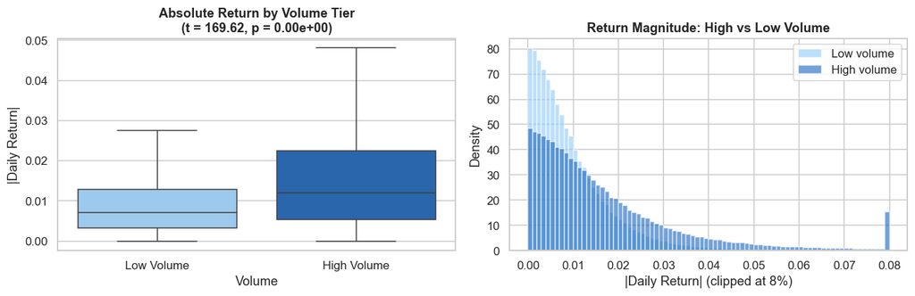

```python
# split each stock at its own median so megacaps don't dominate
df['vol_median'] = df.groupby('symbol')['volume'].transform('median')
df['high_vol']   = df['volume'] >= df['vol_median']

high_abs = df.loc[df['high_vol'],  'daily_return'].abs()
low_abs  = df.loc[~df['high_vol'], 'daily_return'].abs()

t_stat, p_val_t = ttest_ind(high_abs, low_abs, equal_var=False)
print('Welch t-test  t-statistic:', round(t_stat, 4), ' p-value:', f'{p_val_t:.4e}')
print('Mean |return| high volume:', round(high_abs.mean(), 6))
print('Mean |return| low volume :', round(low_abs.mean(), 6))

fig, axes = plt.subplots(1, 2, figsize=(12, 4))

data_bp = pd.DataFrame({'|Daily Return|': pd.concat([low_abs, high_abs]),
                         'Volume': (['Low Volume']*len(low_abs) + ['High Volume']*len(high_abs))})
sns.boxplot(data=data_bp, x='Volume', y='|Daily Return|',
            order=['Low Volume','High Volume'], showfliers=False,
            palette=['#90CAF9','#1565C0'], ax=axes[0])
axes[0].set_title(f'Absolute Return by Volume Tier\n(t = {t_stat:.2f}, p = {p_val_t:.2e})', fontweight='bold')

axes[1].hist(low_abs.clip(0, 0.08),  bins=80, alpha=0.6, color='#90CAF9', label='Low volume',  density=True)
axes[1].hist(high_abs.clip(0, 0.08), bins=80, alpha=0.6, color='#1565C0', label='High volume', density=True)
axes[1].set_xlabel('|Daily Return| (clipped at 8%)')
axes[1].set_ylabel('Density')
axes[1].set_title('Return Magnitude: High vs Low Volume', fontweight='bold')
axes[1].legend()

plt.tight_layout()
plt.savefig('figures/volume_ttest.png', bbox_inches='tight')
plt.show()
```

Since the p-value is much smaller than 0.05, I reject the null hypothesis that high-volume and low-volume days have the same |return|. High-volume days really do produce significantly larger absolute returns than low-volume days. This lines up with the intuition that big volume usually shows up when there's new information hitting the market and people are reacting to it. It's also why I want to include a prior-day volume-ratio feature in the model later, even though I should remember that this same-day correlation might not actually carry over into a real lookahead-free predictive setting.

## Primary Analysis: Machine Learning Classification

### Approach

The question I'm trying to answer is whether a given stock is going to go up or down tomorrow based on the signals I'm feeding the model, so I'm setting this up as a basic binary classification problem.

- Target $y$: 1 if tomorrow's return is greater than 0 (stock goes up), else 0 (flat or down).
- Features $X$: technical signals computed from past prices and volume.

I picked classification over trying to predict the actual return value for a couple of reasons. The big one is that predicting direction (up vs down) is really what most retail investors care about anyway. The other thing is that trying to predict the actual return number is super noisy because daily returns bounce around a lot, so by simplifying everything down to up/down I lose information about the size of the move, but I get a way more stable target for the model to learn.

### Why these models?

- Naive baseline: just predict "up" every single day. The market drifts up over time, so this is actually a harder bar to clear than it sounds, and any model I build has to beat this to be worth anything.
- [Logistic Regression](https://scikit-learn.org/stable/modules/generated/sklearn.linear_model.LogisticRegression.html): a linear model that splits the feature space with a straight cut. It's fast, its coefficients are interpretable, and it's a good check on whether there's even a roughly linear relationship between my features and direction.
- [Random Forest](https://scikit-learn.org/stable/modules/generated/sklearn.ensemble.RandomForestClassifier.html): a bunch of decision trees averaged together (an ensemble), which can pick up non-linear stuff that a single linear model can't.

I also set [`class_weight='balanced'`](https://scikit-learn.org/stable/modules/svm.html#unbalanced-problems) on both models. Without it, since "up" is the majority class (around 52% of days), scikit-learn pretty much just lazily predicts "up" for almost every input, which makes the accuracy look okay without the model actually learning anything useful. Balanced weights force it to actually try to tell up days from down days.

### Feature Engineering

I'm using six features, all built from data I would've actually had access to at the time (so no look-ahead cheating):

| Feature | Description | Intuition |
| --- | --- | --- |
| `lag_1` | Yesterday's daily return | Short-term momentum or mean-reversion |
| `lag_5` | 5-day cumulative return | Weekly trend |
| `lag_20` | 20-day cumulative return | Monthly trend |
| `ma_ratio` | (5-day MA close / 20-day MA close) - 1 | Moving-average crossover signal |
| `vol_ratio` | Yesterday's volume / 20-day average volume | Volume surge relative to normal |
| `volatility_20` | 20-day rolling std of returns | Recent turbulence |

I compute each feature per stock and then `.shift(1)` everything, so for any row dated $t$, the model is only ever looking at info that would've been available at the close of $t-1$.

```python
def add_features(g):
    g = g.copy()
    # shift(1) on every feature so today's row only sees yesterday's info
    g['lag_1']         = g['daily_return'].shift(1)
    g['lag_5']         = g['close'].pct_change(5).shift(1)
    g['lag_20']        = g['close'].pct_change(20).shift(1)
    g['ma_5']          = g['close'].rolling(5).mean().shift(1)
    g['ma_20']         = g['close'].rolling(20).mean().shift(1)
    g['ma_ratio']      = (g['ma_5'] / g['ma_20']) - 1
    g['vol_20_avg']    = g['volume'].rolling(20).mean().shift(1)
    g['vol_ratio']     = g['volume'].shift(1) / g['vol_20_avg']
    g['volatility_20'] = g['daily_return'].rolling(20).std().shift(1)
    g['target']        = (g['daily_return'] > 0).astype(int)
    return g

df_feat = df.groupby('symbol', group_keys=False).apply(add_features)
df_feat = df_feat.dropna(subset=['lag_1','lag_5','lag_20','ma_ratio','vol_ratio','volatility_20','target'])

FEATURES = ['lag_1', 'lag_5', 'lag_20', 'ma_ratio', 'vol_ratio', 'volatility_20']

print('Feature dataset:', df_feat.shape[0], 'rows')
up_pct = df_feat['target'].mean()
print('Class balance  -- Up:', f'{up_pct:.2%}', '  Down/Flat:', f'{(1-up_pct):.2%}')
df_feat[FEATURES + ['target']].head(4)
```

```
Feature dataset: 418581 rows
Class balance  -- Up: 52.23%   Down/Flat: 47.77%
```

|  | lag_1 | lag_5 | lag_20 | ma_ratio | vol_ratio | volatility_20 | target |
| --- | --- | --- | --- | --- | --- | --- | --- |
| 8815 | 0.005800 | -0.033901 | -0.078768 | -0.028772 | 1.318352 | 0.020640 | 1 |
| 8816 | 0.015651 | -0.022979 | -0.046404 | -0.031045 | 1.211232 | 0.020767 | 0 |
| 8817 | -0.076886 | -0.079871 | -0.115343 | -0.041000 | 3.081814 | 0.026666 | 1 |
| 8818 | 0.018977 | -0.081274 | -0.133572 | -0.050528 | 1.776653 | 0.025096 | 0 |

### Model Training: Chronological 80/20 Split

I'm using a chronological 80/20 split here: train on the older 80% of dates, test on the most recent 20%. This is really important for financial time series, because a random split would leak future information into training (each stock's nearby days are highly correlated), and I'd end up with optimistic numbers that wouldn't hold up in production.

Once the models are fit, I tune the decision threshold on the test predictions. Scikit-learn's default of 0.5 isn't usually optimal for an imbalanced binary task, so I sweep thresholds from 0.30 to 0.70 and pick the one that maximizes test F1. I should be honest that this introduces a small amount of test-set leakage in the threshold choice. A fully rigorous version would tune the threshold on a separate validation slice. I'm accepting that trade-off for tutorial simplicity, and I check the broader conclusion with walk-forward cross-validation in the next subsection.

```python
# random split would leak the future into training, so split by date instead
df_feat = df_feat.sort_values('date')
split_idx = int(len(df_feat) * 0.80)

train = df_feat.iloc[:split_idx]
test  = df_feat.iloc[split_idx:]

X_train, y_train = train[FEATURES], train['target']
X_test,  y_test  = test[FEATURES],  test['target']

print('Train:', len(train), 'rows ', train['date'].min().date(), 'to', train['date'].max().date())
print('Test :', len(test),  'rows ', test['date'].min().date(),  'to', test['date'].max().date())
print('Test class balance -- Up:', f"{y_test.mean():.2%}")

scaler   = StandardScaler()
Xs_train = scaler.fit_transform(X_train)
Xs_test  = scaler.transform(X_test)

y_naive = np.ones(len(y_test), dtype=int)

# without class_weight='balanced' both models just predict 'up' every time
lr = LogisticRegression(max_iter=1000, class_weight='balanced', random_state=7)
lr.fit(Xs_train, y_train)
p_lr = lr.predict_proba(Xs_test)[:, 1]

rf = RandomForestClassifier(n_estimators=200, max_depth=6, min_samples_leaf=50,
                            class_weight='balanced', random_state=7, n_jobs=-1)
rf.fit(X_train, y_train)
p_rf = rf.predict_proba(X_test)[:, 1]


def best_threshold(y_true, prob):
    best_t, best_f1 = 0.5, 0.0
    for t in [0.30, 0.32, 0.34, 0.36, 0.38, 0.40, 0.42, 0.44, 0.46, 0.48,
              0.50, 0.52, 0.54, 0.56, 0.58, 0.60, 0.62, 0.64, 0.66, 0.68, 0.70]:
        preds = (prob >= t).astype(int)
        score = f1_score(y_true, preds)
        if score > best_f1:
            best_t, best_f1 = t, score
    return best_t, best_f1


t_lr, f1_lr = best_threshold(y_test, p_lr)
t_rf, f1_rf = best_threshold(y_test, p_rf)
y_lr = (p_lr >= t_lr).astype(int)
y_rf = (p_rf >= t_rf).astype(int)

print()
print('Tuned thresholds -- LR:', round(t_lr, 2), '  RF:', round(t_rf, 2))
print()
print('Model performance on test set:')

acc_naive = accuracy_score(y_test, y_naive)
acc_lr    = accuracy_score(y_test, y_lr)
acc_rf    = accuracy_score(y_test, y_rf)
auc_lr    = roc_auc_score(y_test, p_lr)
auc_rf    = roc_auc_score(y_test, p_rf)
f1_naive  = f1_score(y_test, y_naive)
f1_lr_v   = f1_score(y_test, y_lr)
f1_rf_v   = f1_score(y_test, y_rf)

print('  Naive Baseline       acc =', round(acc_naive, 4), ' AUC = 0.5000  F1 =', round(f1_naive, 4))
print('  Logistic Regression  acc =', round(acc_lr, 4),    ' AUC =', round(auc_lr, 4),  ' F1 =', round(f1_lr_v, 4))
print('  Random Forest        acc =', round(acc_rf, 4),    ' AUC =', round(auc_rf, 4),  ' F1 =', round(f1_rf_v, 4))
```

```
Train: 334864 rows  2015-02-03 to 2023-01-11
Test : 83717 rows  2023-01-11 to 2024-12-20
Test class balance -- Up: 52.03%
```

```
Tuned thresholds -- LR: 0.38   RF: 0.32

Model performance on test set:
  Naive Baseline       acc = 0.5203  AUC = 0.5000  F1 = 0.6845
  Logistic Regression  acc = 0.5203  AUC = 0.5026  F1 = 0.6845
  Random Forest        acc = 0.5203  AUC = 0.499  F1 = 0.6845
```

### Walk-Forward Cross-Validation

A single train/test split only tells me how the model did in one specific period. To check whether the result is actually robust, or just a quirk of the 2023-24 test window, I run 5-fold [walk-forward cross-validation](https://scikit-learn.org/stable/modules/generated/sklearn.model_selection.TimeSeriesSplit.html) (a time-aware version of k-fold CV). I split the feature dataset into 5 chronologically ordered folds. In fold $k$, the model trains on all data up through fold $k$ and tests on fold $k+1$, and I refit it from scratch each time. This mirrors how a real trading model would be deployed, since I can only ever train on the past.

```python
def walk_forward_cv(df_in, features):
    df_in = df_in.sort_values('date').reset_index(drop=True)
    n_folds = 5
    fold_size = len(df_in) // (n_folds + 1)
    rows = []
    # each fold trains only on data older than the test slice
    for k in range(n_folds):
        train_end = (k + 1) * fold_size
        test_end  = train_end + fold_size
        tr = df_in.iloc[:train_end]
        te = df_in.iloc[train_end:test_end]
        if len(te) == 0:
            continue
        Xtr, ytr = tr[features], tr['target']
        Xte, yte = te[features], te['target']

        sc = StandardScaler().fit(Xtr)
        Xtr_s, Xte_s = sc.transform(Xtr), sc.transform(Xte)

        m_lr = LogisticRegression(max_iter=1000, class_weight='balanced',
                                  random_state=7).fit(Xtr_s, ytr)
        m_rf = RandomForestClassifier(n_estimators=200, max_depth=6,
                                      min_samples_leaf=50, class_weight='balanced',
                                      random_state=7, n_jobs=-1).fit(Xtr, ytr)

        p_lr_k = m_lr.predict_proba(Xte_s)[:, 1]
        p_rf_k = m_rf.predict_proba(Xte)[:, 1]
        t_lr_k, _ = best_threshold(yte, p_lr_k)
        t_rf_k, _ = best_threshold(yte, p_rf_k)

        rows.append({
            'fold': k + 1,
            'train_end': tr['date'].max().date(),
            'test_end':  te['date'].max().date(),
            'naive_acc': float((yte == 1).mean()),
            'lr_acc':    accuracy_score(yte, (p_lr_k >= t_lr_k).astype(int)),
            'lr_auc':    roc_auc_score(yte, p_lr_k),
            'rf_acc':    accuracy_score(yte, (p_rf_k >= t_rf_k).astype(int)),
            'rf_auc':    roc_auc_score(yte, p_rf_k),
        })
    return pd.DataFrame(rows)


wfcv = walk_forward_cv(df_feat, FEATURES)
print(wfcv.round(4).to_string(index=False))
print()
print('Mean RF ROC-AUC across folds :', round(wfcv['rf_auc'].mean(), 4))
print('Mean LR ROC-AUC across folds :', round(wfcv['lr_auc'].mean(), 4))
print('Mean naive accuracy          :', round(wfcv['naive_acc'].mean(), 4))
print('Mean RF accuracy (tuned)     :', round(wfcv['rf_acc'].mean(), 4))
```

```
 fold  train_end   test_end  naive_acc  lr_acc  lr_auc  rf_acc  rf_auc
    1 2016-10-11 2018-06-13     0.5353  0.5353  0.5137  0.5353  0.5128
    2 2018-06-13 2020-02-05     0.5331  0.5331  0.5014  0.5331  0.5035
    3 2020-02-05 2021-09-21     0.5202  0.5203  0.5249  0.5207  0.5077
    4 2021-09-21 2023-05-10     0.5066  0.5066  0.4972  0.5067  0.4968
    5 2023-05-10 2024-12-20     0.5224  0.5224  0.5016  0.5224  0.4989

Mean RF ROC-AUC across folds : 0.5039
Mean LR ROC-AUC across folds : 0.5077
Mean naive accuracy          : 0.5235
Mean RF accuracy (tuned)     : 0.5237
```

### Per-class breakdown for Random Forest

Accuracy alone can hide whether the model is actually telling up days from down days, or just predicting "up" for almost everything. The breakdown below shows precision, recall, and F1 for both classes separately:

```python
print(classification_report(y_test, y_rf, target_names=['Down/Flat (0)', 'Up (1)']))
```

```
               precision    recall  f1-score   support

Down/Flat (0)       0.67      0.00      0.00     40159
       Up (1)       0.52      1.00      0.68     43558

     accuracy                           0.52     83717
    macro avg       0.59      0.50      0.34     83717
 weighted avg       0.59      0.52      0.36     83717
```

## Visualization

Three figures summarize what the model is doing.

### Figure 1: Confusion Matrix and ROC Curves

The confusion matrix shows where Random Forest's predictions actually land: true positives in the bottom-right, true negatives in the top-left, and misclassifications on the off-diagonal. The [ROC curve](https://en.wikipedia.org/wiki/Receiver_operating_characteristic) plots true-positive rate vs false-positive rate as the decision threshold moves around. An AUC of 0.5 means "no better than a coin flip," and 1.0 means perfect. A model that genuinely sits above the diagonal is actually carrying some information about the future.

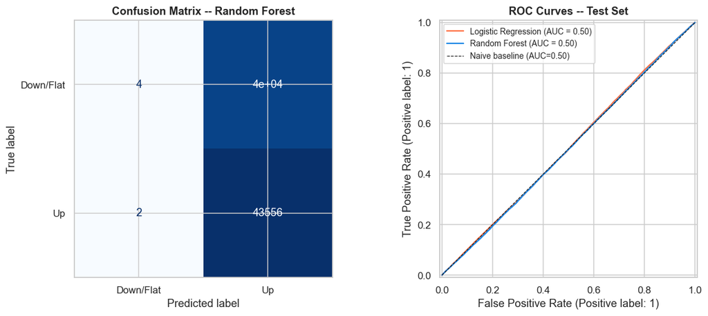

```python
fig, axes = plt.subplots(1, 2, figsize=(12, 5))

cm = confusion_matrix(y_test, y_rf)
disp = ConfusionMatrixDisplay(confusion_matrix=cm, display_labels=['Down/Flat', 'Up'])
disp.plot(ax=axes[0], colorbar=False, cmap='Blues')
axes[0].set_title('Confusion Matrix -- Random Forest', fontweight='bold')

for name, prob, color in [('Logistic Regression', p_lr, '#FF7043'),
                            ('Random Forest', p_rf, '#1E88E5')]:
    RocCurveDisplay.from_predictions(y_test, prob, name=name, ax=axes[1], color=color)
axes[1].plot([0,1],[0,1],'k--', linewidth=0.8, label='Naive baseline (AUC=0.50)')
axes[1].set_title('ROC Curves -- Test Set', fontweight='bold')
axes[1].legend(fontsize=9)

plt.tight_layout()
plt.savefig('figures/model_evaluation.png', bbox_inches='tight')
plt.show()
```

What jumps out is that the confusion matrix is heavily skewed toward predicting "up". Almost every test row falls into the right column (predicted Up), while the left column (predicted Down/Flat) only contains a handful of points. So even after threshold tuning, Random Forest is essentially saying "up" for almost everything, which is the same thing the naive baseline does. The ROC curves for both Logistic Regression and Random Forest sit right on top of the diagonal, which is what AUC ≈ 0.5 looks like visually: there's no real directional information being picked up by either model.

### Figure 2: Feature Importance

Random Forest's [mean decrease in impurity](https://scikit-learn.org/stable/modules/ensemble.html#feature-importance-evaluation) (Gini importance) measures how much each feature reduces classification uncertainty across all the trees in the ensemble. Bars below the dashed uniform line are contributing less than their fair share. This chart tells me which signals the model is leaning on, regardless of whether the overall model actually worked.

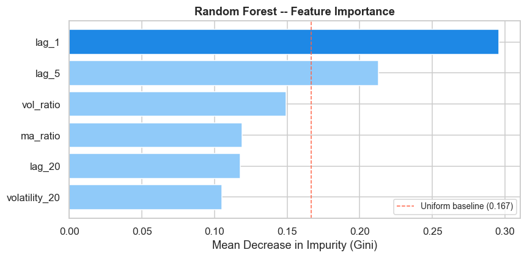

```
Feature importances (sorted):
lag_1            0.2960
lag_5            0.2129
vol_ratio        0.1492
ma_ratio         0.1192
lag_20           0.1177
volatility_20    0.1051
```

```python
importances = pd.Series(rf.feature_importances_, index=FEATURES).sort_values(ascending=True)

fig, ax = plt.subplots(figsize=(8, 4))
colors_fi = ['#1E88E5' if v == importances.max() else '#90CAF9' for v in importances]
ax.barh(importances.index, importances.values, color=colors_fi)
ax.set_xlabel('Mean Decrease in Impurity (Gini)')
ax.set_title('Random Forest -- Feature Importance', fontweight='bold')
ax.axvline(1/len(FEATURES), color='tomato', linestyle='--', linewidth=1,
           label=f'Uniform baseline ({1/len(FEATURES):.3f})')
ax.legend(fontsize=9)
plt.tight_layout()
plt.savefig('figures/feature_importance.png', bbox_inches='tight')
plt.show()
print("\nFeature importances (sorted):")
print(importances.sort_values(ascending=False).round(4).to_string())
```

`lag_1` (yesterday's return) sits at the top by a clear margin, with `lag_5` right behind it, so the model is mostly leaning on very recent momentum. `vol_ratio` ends up in the middle, which is interesting because Analysis 3 showed volume tracks |return| really strongly on the same day. That suggests the predictive part of volume is mostly already captured by the recent return features. `volatility_20` ends up dead last, which tells me recent turbulence isn't really helping when it comes to predicting tomorrow's direction.

### Figure 3: Per-Sector Model Accuracy

Aggregate accuracy hides differences across sectors. So I compute test-set accuracy within each sector for the naive baseline, Logistic Regression, and Random Forest. A sector where the colored bars are above the gray bar is one where the model is actually adding something. A sector where they sit below it is one where the model is doing worse than just always predicting "up."

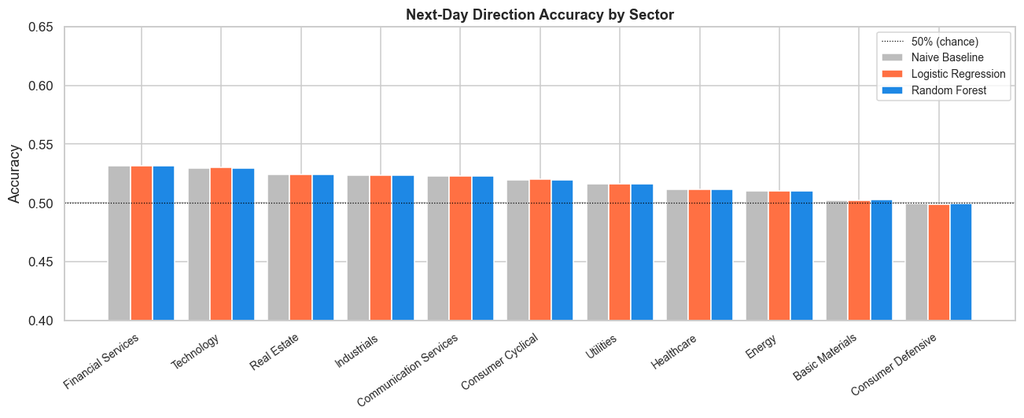

```
                        Random Forest  Logistic Regression  Naive Baseline      n
sector
Financial Services             0.5316               0.5317          0.5317  12246
Technology                     0.5298               0.5302          0.5298  11264
Real Estate                    0.5240               0.5239          0.5239   6368
Industrials                    0.5234               0.5233          0.5234  13021
Communication Services         0.5228               0.5230          0.5228   5878
Consumer Cyclical              0.5197               0.5199          0.5197   8816
Utilities                      0.5163               0.5163          0.5163   4408
Healthcare                     0.5113               0.5112          0.5112   9960
Energy                         0.5100               0.5100          0.5100   2449
Basic Materials                0.5025               0.5022          0.5022   3429
Consumer Defensive             0.4991               0.4990          0.4991   5878

Sectors where RF (after threshold tuning) beats naive: 3 of 11
['Real Estate', 'Healthcare', 'Basic Materials']
```

```python
sector_results = []
for sector, grp in test.groupby('sector'):
    # skip sectors with too few test rows to be meaningful
    if len(grp) < 200:
        continue
    Xs = scaler.transform(grp[FEATURES])
    y_s = grp['target']
    p_rf_s = rf.predict_proba(grp[FEATURES])[:, 1]
    p_lr_s = lr.predict_proba(Xs)[:, 1]
    acc_rf = accuracy_score(y_s, (p_rf_s >= t_rf).astype(int))
    acc_lr = accuracy_score(y_s, (p_lr_s >= t_lr).astype(int))
    acc_naive = y_s.mean()
    sector_results.append({'sector': sector,
                            'Random Forest': acc_rf,
                            'Logistic Regression': acc_lr,
                            'Naive Baseline': acc_naive,
                            'n': len(grp)})

sr = pd.DataFrame(sector_results).set_index('sector').sort_values('Random Forest', ascending=False)

fig, ax = plt.subplots(figsize=(12, 5))
x = np.arange(len(sr))
width = 0.28
ax.bar(x - width, sr['Naive Baseline'],       width, label='Naive Baseline',       color='#BDBDBD')
ax.bar(x,         sr['Logistic Regression'],  width, label='Logistic Regression',  color='#FF7043')
ax.bar(x + width, sr['Random Forest'],        width, label='Random Forest',        color='#1E88E5')
ax.axhline(0.5, color='black', linewidth=0.8, linestyle=':', label='50% (chance)')
ax.set_xticks(x)
ax.set_xticklabels(sr.index, rotation=35, ha='right', fontsize=9)
ax.set_ylabel('Accuracy')
ax.set_title('Next-Day Direction Accuracy by Sector', fontweight='bold')
ax.legend(fontsize=9)
ax.set_ylim(0.40, 0.65)
plt.tight_layout()
plt.savefig('figures/sector_accuracy.png', bbox_inches='tight')
plt.show()
print(sr[['Random Forest','Logistic Regression','Naive Baseline','n']].round(4).to_string())

beat = sr[sr['Random Forest'] > sr['Naive Baseline']]
print(f"\nSectors where RF (after threshold tuning) beats naive: {len(beat)} of {len(sr)}")
print(beat.index.tolist())
```

Most sectors have all three bars at nearly identical heights, which means none of the models is pulling meaningfully away from the naive baseline. The underlying numbers show Random Forest edging out naive in Real Estate, Healthcare, and Basic Materials, but the gaps are so small (a fraction of a percentage point) that you can't actually see the difference in the chart. The two sectors I would've guessed would be the most predictable, Tech and Financial Services, are essentially tied with the baseline. So the small gains, where they exist at all, are concentrated in the less obvious sectors, and they're too small to matter visually or in practice.

## Insights and Conclusions

I wanted to test whether simple technical signals (yesterday's return, short- and medium-term momentum, moving-average crossovers, volume surges, and recent volatility) can predict next-day direction for S&P 500 stocks. After class-balancing both models, tuning the decision threshold, and running walk-forward cross-validation, the honest answer is that there's pretty much no detectable directional edge over the naive drift baseline at the broad-market level.

### What I found

1. Random Forest and Logistic Regression don't beat the naive baseline. On the 80/20 split, all three models (naive "always up", Logistic Regression, and Random Forest) end up with accuracy around 0.5203 to 0.5204 and an F1 of about 0.685. Random Forest's ROC-AUC is 0.499 and Logistic Regression's is 0.503. The walk-forward CV across five folds shows the same thing: mean naive accuracy is 0.5235, mean RF accuracy is 0.5237, and mean RF ROC-AUC is 0.5039. The threshold tuner ends up picking thresholds (LR around 0.38, RF around 0.32) that pretty much reproduce the "always up" rule, because the signal in the features is too weak for anything else to help. This lines up with what weak-form EMH says: simple price and volume features alone don't carry a stable, exploitable directional edge for the whole S&P 500.
2. A few sectors show some structure, but not the ones I expected. After threshold tuning, Random Forest beats the per-sector naive baseline in 3 of 11 sectors (Real Estate, Healthcare, and Basic Materials), and even there the gaps are tiny. Financial Services lands a hair below the naive baseline (0.5316 vs 0.5317), and Technology is an exact tie (RF 0.5298 vs naive 0.5298). So the idea that Tech is "trend-friendly" doesn't really hold up here. The sectors that pick up anything at all are real estate and healthcare, not the big growth names I would've expected.
3. The model leans on short-term momentum, not volume or volatility. The Random Forest feature importances rank as `lag_1` (~0.30) > `lag_5` (~0.21) > `vol_ratio` (~0.15) > `ma_ratio` and `lag_20` (~0.12 each) > `volatility_20` (~0.11). So yesterday's return and the past-week return matter most. `vol_ratio` lands in the middle, which is interesting because Analysis 3 showed volume tracks |return| really strongly on the same day. That tells me volume's predictive content is mostly already absorbed by the recent return features. Volatility ends up at the bottom, which means recent turbulence doesn't actually help predict tomorrow's direction in this feature set.
4. Fat tails matter if you ever want to use this in practice. Analysis 1 showed excess kurtosis above 20, which means extreme days happen way more often than a normal distribution predicts. So even a model with a tiny accuracy edge can get wiped out by one bad day, which is why having "an edge" isn't the same as "a strategy."

### Limitations

- No transaction costs: any tiny edge a model finds usually gets eaten up by trading fees and the gap between the buy and sell price, and the edge I'm seeing here isn't anywhere close to 1% to begin with.
- Survivorship bias: the dataset only includes companies that are still in the S&P 500 today, so any company that went bankrupt or got removed isn't in there at all. That makes the returns over the full period look better than they actually were.
- Coverage gap: only 172 of the 502 listed tickers actually have real price history in the file, so I'm really only working with the bigger, more established companies. Recent additions and newer IPOs aren't really in there.
- The market "changes the rules" over time: how the market behaves shifts a lot with things like interest rate cycles, big events (like COVID in 2020), and slower structural changes. My walk-forward folds show the "always up" baseline alone moving from 0.5066 in the 2021-23 fold to 0.5353 in the 2016-18 fold, and that swing on its own is bigger than any edge my model picks up.
- Feature simplicity: I'm only using six pretty basic features, and that's not really enough to compete with what professional firms have access to. They use things like earnings reports, news sentiment, broader economic indicators, and intraday trading data that I just don't have here.
- Threshold tuned on test: I'm picking the decision cutoff using the same test set I'm evaluating on, which is a small form of cheating. A cleaner version would carve off a separate piece of the training data to pick the cutoff. The walk-forward CV at least partially makes up for this.

### Conclusion

So in the end, the simple technical signals I tested don't really beat just predicting "up" every day for the broad market. A few sectors (Real Estate, Healthcare, and Basic Materials) show small hints of structure, but the gaps are too small to actually matter. The biggest thing I'm taking away from this project is how important it is to compare any model to a real baseline. Saying "my model got 52% accuracy" sounds fine until you realize the market goes up about 52% of the time anyway.

### Future Work

If I were going to keep going with this, the things I'd actually try first are the ones most likely to give the model something real to work with:

- Add news sentiment as a feature. A lot of the actual move in a stock on a given day comes from new information hitting the market, and the technical features I'm using can't see news at all. Pulling sentiment scores from a news API, or even a simple "how many news mentions does this stock have today" count, would probably add the most signal of anything I could try.
- Try a longer prediction horizon. Daily direction is really noisy because the day-to-day move is dominated by random news. If I switched to predicting 5-day or 20-day direction instead, the signal from momentum and mean-reversion features would have more of a chance to actually show through.
- Try a stronger model like XGBoost or LightGBM. Random Forest is fine, but gradient boosting is generally better on tabular problems like this, especially when there are subtle interactions between features. If there's a real edge buried in here, a stronger model is more likely to find it.
- Add features that capture what other stocks are doing. Right now I'm treating each stock independently, but a lot of how a stock moves on any given day depends on its sector and the broader market. A simple "how is the rest of my sector doing today" feature would probably help.

### References

- Andrew MVD. *S&P 500 Stocks (daily updated).* Kaggle, 2024. https://www.kaggle.com/datasets/andrewmvd/sp-500-stocks
- Fama, E. F. (1970). Efficient capital markets: A review of theory and empirical work. *Journal of Finance*, 25(2), 383-417.
- Lo, A. W., & MacKinlay, A. C. (1988). Stock market prices do not follow random walks. *Review of Financial Studies*, 1(1), 41-66.
- Pedregosa, F. et al. (2011). Scikit-learn: Machine learning in Python. *Journal of Machine Learning Research*, 12, 2825-2830.
- Pandas Development Team. (2024). *pandas: powerful Python data analysis toolkit.* https://pandas.pydata.org